# Homework 2

#### Question 2

ANSWER: If I had to apply one of the above simple tests from question 1, I would conduct a *two sample t-test* given normal distribution and equal variance because you are comparing the mean cortex weight between two groups - the treatment and control. However a two sample t-test would not include the factor, experiment number, and because the experiementers wanted to repeat their experiments to test an effect of toys on cortex weight, a two sample t-test would be insufficient.

I think a more reasonable test to conduct would be a *linear regression model* with the dependent variable (Y = cortex weight) and independent variables (X1 = toy allowance and X1 = experiment #) to test the association between toys and cortex development. The variable toy allowance would be a factor with two levels - given toys (treatment) or not given toys (control). However other variables, or confounders, in this study could be individual rat weight, overall rat health, etc.

#### Question 3

ANSWER: The permutation test was ran with the below hypotheses and the results are summarized with a histogram.

- H0 (null hypothesis): The amount of hemogloblin associated with honey group is equal to amount of hemogloblin associated with non honey group (mu_difference = 0)
- HA (alternative hypothesis): The amount of hemogloblin associated with honey group is not equal to amount of hemogloblin associated with non honey group.

```r
library(coin)
```

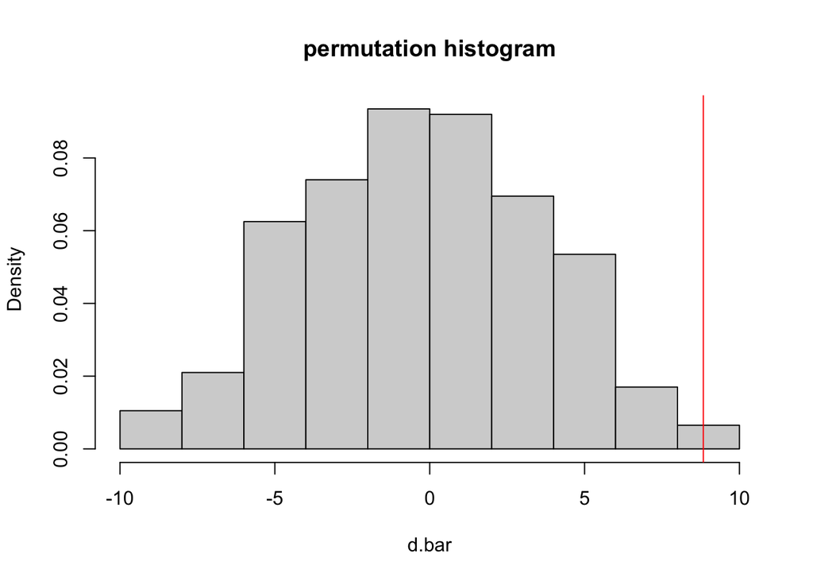

```r
## upload data
honey <- c(19,12,9,17,24,24)
no_honey <- c(14,8,4,4,11,11)

## run permuation test

d <- honey - no_honey # difference between honey and no honey
n <- length(d) # create vector of length of d

d.perm <- matrix(abs(d), n, 1000) # create empty matrix
d.perm <- d.perm*sign(runif(1000*n) - .5) # fill in matrix
d.bar <- apply(d.perm, 2, mean)
hist(d.bar, freq = F, main = "permutation histogram")
abline(v = mean(d), col = "red")
```

```r
mean(abs(d.bar) > abs(mean(d)))
```

```
## [1] 0
```

```r
## construct bootstrap confidence intervals for the difference of population means

d <- honey - no_honey # difference between honey and no honey
boot.smpl <- matrix(d, length(d), 1000) # create matrix
boot.smpl <- apply(boot.smpl, 2, sample, r = T) # replace = true
boot.md <- apply(boot.smpl, 2, median)

var(boot.md) # 11.19549
```

```
## [1] 11.84278
```

```r
quantile(boot.md, c(.25, .975)) # create 95% CI
```

```
##   25% 97.5%
##     5    13
```

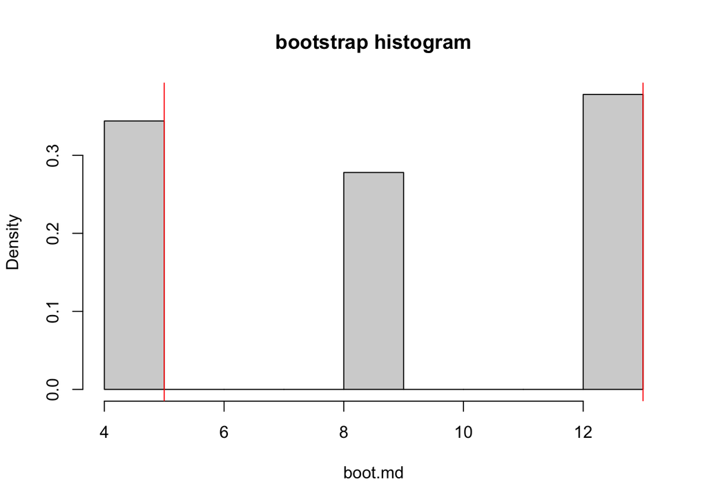

```r
# CI: 5 - 13

hist(boot.md, freq = F, main = "bootstrap histogram") # histogram of bootstrap estimates
abline(v = c(5, 13), col = "red")
```